# HW2 - Ibrahim Gabr (12144496)

```python
import pandas as pd
import warnings
warnings.filterwarnings(action='ignore',category=FutureWarning)
import numpy as np
import seaborn as sns
import matplotlib.pyplot as plt
import statsmodels.api as sm
%matplotlib inline
plt.rcParams["figure.figsize"] = (15,10)
plt.rcParams["xtick.labelsize"] = 16
plt.rcParams["ytick.labelsize"] = 16
plt.rcParams["axes.labelsize"] = 20
plt.rcParams['legend.fontsize'] = 20
pd.options.display.max_columns = 999
from scipy.stats import ttest_ind_from_stats as ttest
plt.rcParams.update({'axes.titlesize': '35'})
plt.rcParams.update({'legend.fontsize': '35'})
```

# Part 1

```python
data = pd.read_stata("MTO_data.dta")
```

```python
data.shape
```

```
(3111, 65)
```

```python
#Let's encode out dummy variabls

data["group_experimental"] = data["group_experimental"].apply(
    lambda x: 0 if x[0] == "0" else 1).astype("float64")
data["group_section8"] = data["group_section8"].apply(
    lambda x: 0 if x[0] == "0" else 1).astype("float64")
data["group_control"] = data["group_control"].apply(
    lambda x: 0 if x[0] == "0" else 1).astype("float64")
data['city_baltimore'] = data['city_baltimore'].apply(
    lambda x: 0 if x[0] == "0" else 1).astype("float64")
data['bmi_40'] = data['bmi_40'].apply(
    lambda x: 0 if x[0] == "0" else 1).astype("float64")
data['anxiety'] = data['anxiety'].apply(
    lambda x: 0 if x[0] == "0" else 1).astype("float64")
```

## Question 1

Please see filled out table produced from code at the end of this question.

```python
col_list = ["male", "head_earnings", "bmi_40","no_family_in_nbhd", "anxiety"]
data[col_list].head()
```

|  | male | head_earnings | bmi_40 | no_family_in_nbhd | anxiety |
| --- | --- | --- | --- | --- | --- |
| 0 | 1.0 | -38480.976562 | 0.0 | 0.0 | 1.0 |
| 1 | 1.0 | 21206.250000 | 1.0 | 1.0 | 1.0 |
| 2 | 0.0 | 13893.000977 | 1.0 | 1.0 | 0.0 |
| 3 | 0.0 | 15571.154297 | 0.0 | 1.0 | 1.0 |
| 4 | 0.0 | 11620.408203 | 0.0 | 0.0 | 0.0 |

```python
experimental_df = data[(data["group_experimental"] == 1.0) &
                       (data["group_section8"] == 0.0) &
                       (data["group_control"] == 0.0)]
section8_df = data[(data["group_experimental"] == 0.0) &
                   (data["group_section8"] == 1.0) &
                   (data["group_control"] == 0.0)]
control_df = data[(data["group_experimental"] == 0.0) &
                  (data["group_section8"] == 0.0) &
                  (data["group_control"] == 1.0)]
```

```python
def fill_values(df):
    male = np.nanmean(np.asarray(df["male"]))
    head_earnings = np.nanmean(np.asarray(df['head_earnings']))
    bmi_40 = np.nanmean(np.asarray(df["bmi_40"]))
    no_family_in_nbhd = np.nanmean(np.asarray(df['no_family_in_nbhd']))
    anxiety = np.nanmean(np.asarray(df["anxiety"]))
    return np.asarray([male, head_earnings,bmi_40, no_family_in_nbhd, anxiety])
```

```python
def generate_stats(df, charac_lst):
    stat_dict = {}
    for c in charac_lst:
        mu = np.nanmean(np.asarray(df[c])) # nanmean to ensure NaN values are omitted
        s = np.nanstd(np.asarray(df[c])) # nanstd to ensure NaN values are omitted
        N = df[c].notnull().sum() # calculates number of non-NaN values
        stat_dict[c] = (mu,s,N)
    return stat_dict
```

```python
def p_values(df1, df2, charac_lst):
    p_dict = {}
    group_1_stats = generate_stats(df1, charac_lst)
    group_2_stats = generate_stats(df2, charac_lst)

    for c in charac_lst:
        m1, s1, n1 = group_1_stats[c]
        m2, s2, n2 = group_2_stats[c]
        p_dict[c] = ttest(m1, s1, n1, m2, s2, n2).pvalue
    return p_dict
```

```python
E = fill_values(experimental_df)
S = fill_values(section8_df)
C = fill_values(control_df)
E_C_diff = E - C
S_C_diff = S - C
S_C_p_vals = p_values(section8_df, control_df, col_list)
E_C_p_vals = p_values(experimental_df, control_df, col_list)
```

```python
table = pd.DataFrame([dict(zip(col_list,E)), dict(zip(col_list,S)),
             dict(zip(col_list,C)), dict(zip(col_list,E_C_diff)),
             E_C_p_vals, dict(zip(col_list, S_C_diff)),
             S_C_p_vals]).T

table.columns = ["Experimental group (E) mean", "Section 8 group (S) mean",
                                      "Control group (C) mean", "Difference E-C",
                                      "p-value E-C", "Difference S-C","p-value S-C"]
table = table.reindex(index=col_list).round(3)

d = dict(selector="th",
    props=[('text-align', 'center')])

table.style.set_properties(**{'width':'10em', 'text-align':'center'})\
        .set_table_styles([d])
```

|  | Experimental group (E) mean | Section 8 group (S) mean | Control group (C) mean | Difference E-C | p-value E-C | Difference S-C | p-value S-C |
| --- | --- | --- | --- | --- | --- | --- | --- |
| male | 0.495 | 0.488 | 0.477 | 0.019 | 0.359 | 0.011 | 0.646 |
| head_earnings | 12708.8 | 12491.8 | 12237.3 | 471.511 | 0.413 | 254.463 | 0.729 |
| bmi_40 | 0.355 | 0.343 | 0.376 | -0.02 | 0.299 | -0.032 | 0.179 |
| no_family_in_nbhd | 0.615 | 0.638 | 0.634 | -0.02 | 0.319 | 0.003 | 0.889 |
| anxiety | 0.365 | 0.353 | 0.358 | 0.007 | 0.738 | -0.005 | 0.818 |

## Compare distributions

Let's verify whether we have balance between the experimental and control groups by looking at the distributions.

By looking at the distributions, it seems that we have balance.

#### Distributions Experiemenal VS Control

```python
experimental_df = data[data['group_section8'] == 0.0]
```

```python
def seaborn_kde_helper(val, color, label):
    return sns.distplot(val, hist=False,color=color, label=label)
```

```python
def gen_distributions(df, character_list):
    for c in character_list:
        print()
        g = sns.FacetGrid(df, hue="group_control", size=15, aspect=2)
        g = g.map(seaborn_kde_helper, c).add_legend()
        plt.ylabel("Density")
        plt.xlabel(f"{c}")
        plt.title(f"Distribution for {c}")
        if c == "head_earnings":
            plt.ylim((0,0.000250))
        else:
            plt.ylim((0,2.3))
```

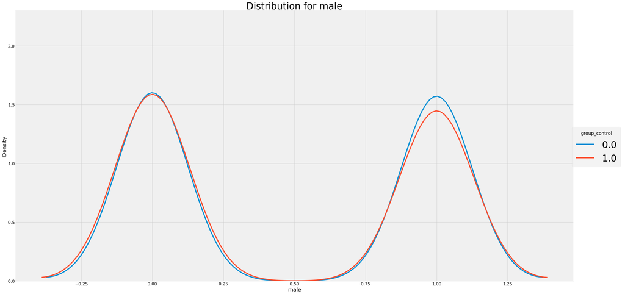

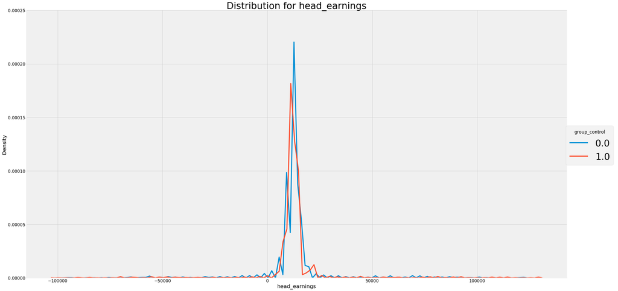

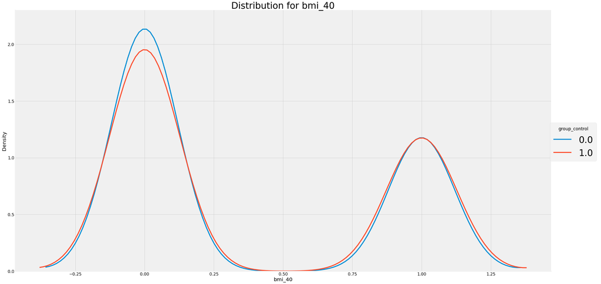

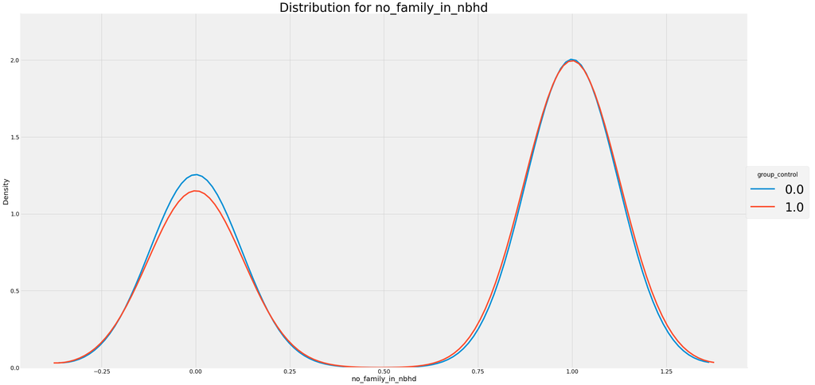

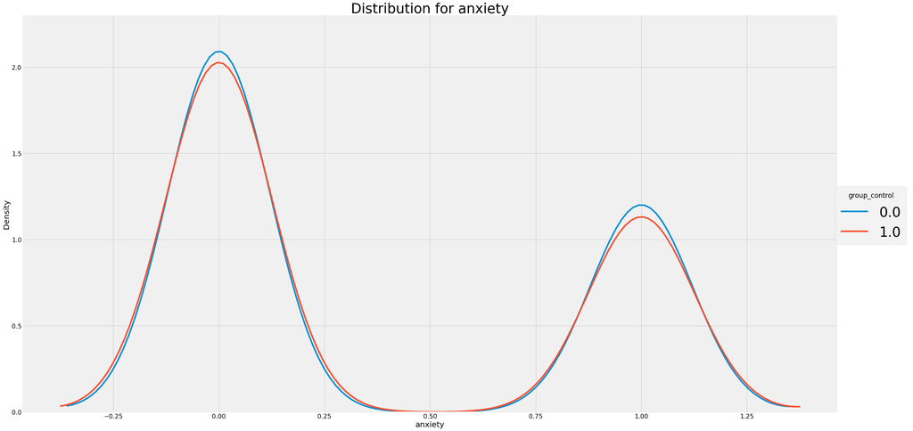

```python
gen_distributions(experimental_df, ["male",
                                    "head_earnings",
                                    "bmi_40",
                                    "no_family_in_nbhd",
                                    "anxiety"])
```

#### Distributions Section 8 VS Control

```python
section8_df = data[data['group_experimental'] == 0.0]
```

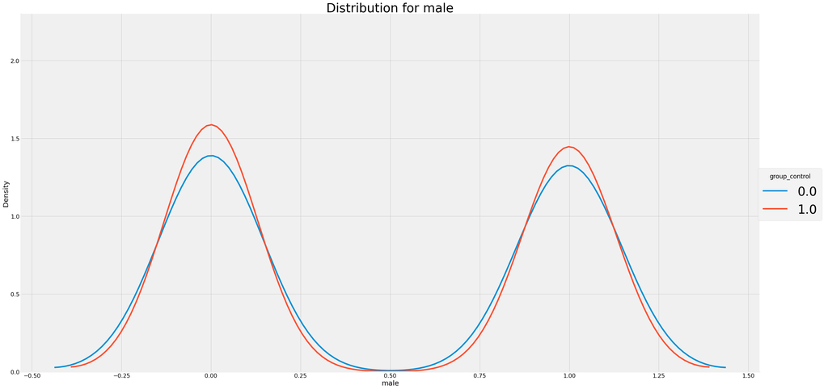

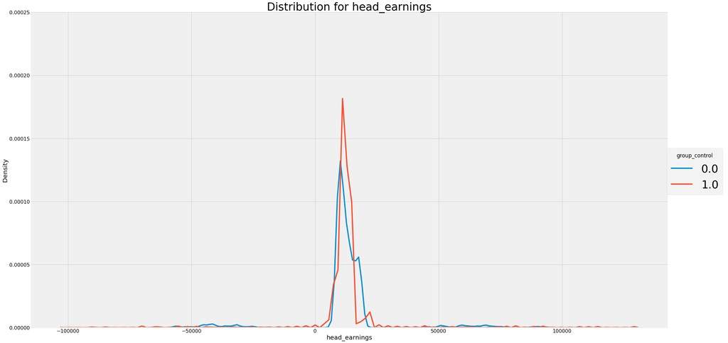

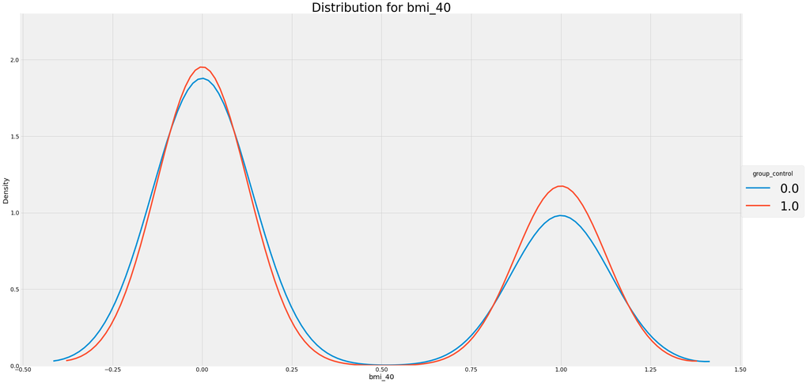

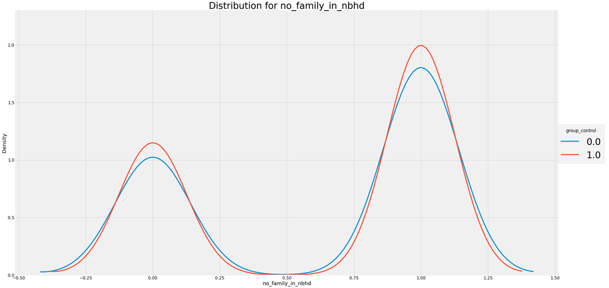

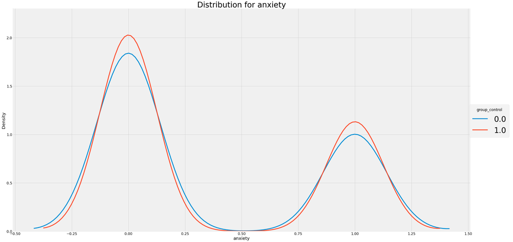

```python
gen_distributions(section8_df, ["male",
                                "head_earnings",
                                "bmi_40",
                                "no_family_in_nbhd",
                                "anxiety"])
```

## Question 2

From the above table, and by looking at the distributions, it is safe to say that the Experimental and Control group is balanced, as is the Section 8 group and the Control group.

It is important to note that we are using the equal variances assumption.

## Question 3

Please find below code output that will match the entries of the table in question 1.

It is important to remember that we have 3 groups. Thus, in order to calculate $E-C$, we must either be in the Experimental Group or in the Control Group.

However, we know for certain that we cannot be in the Section 8 Group.

As such, let's filter our data to ensure `group_section8 == 0.0`.

```python
experimental_df = data[data['group_section8'] == 0.0]

for col in col_list:
    indep = experimental_df["group_experimental"].values
    X = sm.add_constant(indep)
    outcome = experimental_df[col].values

    model = sm.OLS(outcome, X, missing='drop')
    results = model.fit()
    E_minus_C = results.params[-1]
    E_minus_C_p_val = results.pvalues[-1]
    print(f"E-C for {col}: ", E_minus_C)
    print(f"P-Value(E-C) {col}: ", E_minus_C_p_val)
    print()
```

```
E-C for male:  0.0185316536695
P-Value(E-C) male:  0.359643188092

E-C for head_earnings:  471.512058487
P-Value(E-C) head_earnings:  0.413655254893

E-C for bmi_40:  -0.0202397864041
P-Value(E-C) bmi_40:  0.298722896837

E-C for no_family_in_nbhd:  -0.0195192505369
P-Value(E-C) no_family_in_nbhd:  0.319520807539

E-C for anxiety:  0.00650729823508
P-Value(E-C) anxiety:  0.737962562207
```

We now have to filter our data to ensure that `group_experimental == 0.0`

```python
section8_df = data[data['group_experimental'] == 0.0]

for col in col_list:
    indep = section8_df["group_section8"].values
    X = sm.add_constant(indep)
    outcome = section8_df[col].values

    model = sm.OLS(outcome, X, missing='drop')
    results = model.fit()
    E_minus_C = results.params[-1]
    E_minus_C_p_val = results.pvalues[-1]
    print(f"S-C for {col}: ", E_minus_C)
    print(f"P-Value(S-C) {col}: ", E_minus_C_p_val)
    print()
```

```
S-C for male:  0.0114341905986
P-Value(S-C) male:  0.646496631556

S-C for head_earnings:  254.463689042
P-Value(S-C) head_earnings:  0.728720995342

S-C for bmi_40:  -0.0322626490285
P-Value(S-C) bmi_40:  0.178844723388

S-C for no_family_in_nbhd:  0.00333766392237
P-Value(S-C) no_family_in_nbhd:  0.889457446301

S-C for anxiety:  -0.00549386659393
P-Value(S-C) anxiety:  0.818164165874
```

## Question 4

- The Experimental Group made up $44.3\%$ of the data.
- The Section 8 Group made up $20.4\%$ of the data.
- The Control Group made up $35.3\%$ of the data

```python
N = data.shape[0]
experimental_count = data[(data['group_experimental'] == 1.0) &
                          (data['group_section8'] == 0.0) &
                          (data['group_control'] == 0.0)].shape[0]
(experimental_count/N)*100
```

```
44.326583092253294
```

```python
section8_count = data[(data['group_experimental'] == 0.0) &
                      (data['group_section8'] == 1.0) &
                      (data['group_control'] == 0.0)].shape[0]
(section8_count/N)*100
```

```
20.411443265830922
```

```python
control_count = data[(data['group_experimental'] == 0.0) &
                     (data['group_section8'] == 0.0) &
                     (data['group_control'] == 1.0)].shape[0]
(control_count/N)*100
```

```
35.26197364191578
```

## Question 5 - Experimental

- $overall\_index\_z\ ATE : 0.068$.
  - 0.068 std dev's above control groups mean
- $economic\_self\_sufficiency\_z\ ATE : 0.015$
  - 0.015 std dev's above control groups mean
- $absence\_phys\_probs\_z\ ATE : 0.066$
  - 0.066 std dev's above control groups mean
- $absence\_mental\_probs\_z\ ATE : 0.091$
  - 0.091 std dev's above control groups mean
- $psychol\_distress\_z\ ATE : -0.101$
  - 0.1 std dev's below control groups mean

```python
experimental_df = data[(data["group_experimental"] == 1.0) &
                       (data["group_section8"] == 0.0) &
                       (data["group_control"] == 0.0)]
section8_df = data[(data["group_experimental"] == 0.0) &
                   (data["group_section8"] == 1.0) &
                   (data["group_control"] == 0.0)]
control_df = data[(data["group_experimental"] == 0.0) &
                  (data["group_section8"] == 0.0) &
                  (data["group_control"] == 1.0)]
```

```python
round(experimental_df['overall_index_z'].mean() -
      control_df["overall_index_z"].mean(),3)
```

```
0.068
```

```python
round(experimental_df['economic_self_sufficiency_z'].mean() -
      control_df["economic_self_sufficiency_z"].mean(),3)
```

```
0.015
```

```python
round(experimental_df['absence_phys_probs_z'].mean() -
      control_df["absence_phys_probs_z"].mean(),3)
```

```
0.066
```

```python
round(experimental_df['absence_mental_probs_z'].mean() -
      control_df["absence_mental_probs_z"].mean(),3)
```

```
0.091
```

```python
round(experimental_df['psychol_distress_z'].mean() -
      control_df["psychol_distress_z"].mean(),3)
```

```
-0.101
```

## Question 6 - Section 8

- $overall\_index\_z\ ATE : 0.044$.
  - 0.044 std dev's above control groups mean
- $economic\_self\_sufficiency\_z\ ATE : -0.047$
  - 0.047 std dev's below control groups mean
- $absence\_phys\_probs\_z\ ATE : 0.063$
  - 0.063 std dev's above control groups mean
- $absence\_mental\_probs\_z\ ATE : 0.094$
  - 0.094 std dev's above control groups mean
- $psychol\_distress\_z\ ATE : -0.126$
  - 0.126 std dev's below control groups mean

When looking at Section 8 Group ATE's, we see a change in direction for the `economic_self_sufficiency_z` variable.

This might be due to the fact that individuals in this group were not forced to move to a less impoverished area. As such, they may have moved to an even poorer neighbourhood or used the subsidy on goods other than rent.

```python
round(section8_df['overall_index_z'].mean() -
      control_df["overall_index_z"].mean(),3)
```

```
0.044
```

```python
round(section8_df['economic_self_sufficiency_z'].mean() -
      control_df["economic_self_sufficiency_z"].mean(),3)
```

```
-0.047
```

```python
round(section8_df['absence_phys_probs_z'].mean() -
      control_df["absence_phys_probs_z"].mean(),3)
```

```
0.063
```

```python
round(section8_df['absence_mental_probs_z'].mean() -
      control_df["absence_mental_probs_z"].mean(),3)
```

```
0.094
```

```python
round(section8_df['psychol_distress_z'].mean() -
      control_df["psychol_distress_z"].mean(),3)
```

```
-0.126
```

## Question 7

The std error for every bivariate regression is 0.04. This is small, relative to the magnitude of the coefficients - this is a good sign as large standard errors lead to imprecise coefficients as would be evident by having a large confidence interval.

Significant at 90% level:

- `overall_index_z`

Significant at 95% level:

- `absence_mental_probs_z`
- `psychol_distress_z`

```python
# Experimental Group

lst = ["overall_index_z", "economic_self_sufficiency_z",
       "absence_phys_probs_z", "absence_mental_probs_z",
       "psychol_distress_z"]

experimental_df = data[data['group_section8'] == 0.0]

for y in lst:
    indep = experimental_df["group_experimental"].values
    X = sm.add_constant(indep)
    outcome = experimental_df[y].values

    model = sm.OLS(outcome, X, missing='drop')
    results = model.fit()
    coeff = round(results.params[-1],3)
    p_val = round(results.pvalues[-1],3)
    std_error = round(results.bse[-1],3)
    r2 = round(results.rsquared,3)
    print(f"coeff for {y}: ", coeff)
    print(f"Std Error for {y}: ", std_error)
    print(f"P-Value for {y}: ", p_val)
    print(f"R^2 for {y}: ", r2)
    if p_val <= 0.05:
        print(f"{y} is significant at 95% Level")
    elif p_val <= 0.1:
        print(f"{y} is significant at 90% Level")
    else:
        print(f"{y} is not significant at 95% or 90 % Level")
    print()
```

```
coeff for overall_index_z:  0.068
Std Error for overall_index_z:  0.04
P-Value for overall_index_z:  0.086
R^2 for overall_index_z:  0.001
overall_index_z is significant at 90% Level

coeff for economic_self_sufficiency_z:  0.015
Std Error for economic_self_sufficiency_z:  0.04
P-Value for economic_self_sufficiency_z:  0.707
R^2 for economic_self_sufficiency_z:  0.0
economic_self_sufficiency_z is not significant at 95% or 90 % Level

coeff for absence_phys_probs_z:  0.066
Std Error for absence_phys_probs_z:  0.04
P-Value for absence_phys_probs_z:  0.101
R^2 for absence_phys_probs_z:  0.001
absence_phys_probs_z is not significant at 95% or 90 % Level

coeff for absence_mental_probs_z:  0.091
Std Error for absence_mental_probs_z:  0.04
P-Value for absence_mental_probs_z:  0.023
R^2 for absence_mental_probs_z:  0.002
absence_mental_probs_z is significant at 95% Level

coeff for psychol_distress_z:  -0.101
Std Error for psychol_distress_z:  0.039
P-Value for psychol_distress_z:  0.01
R^2 for psychol_distress_z:  0.003
psychol_distress_z is significant at 95% Level
```

## Question 8

All of the coefficients match those that we calculated by comparing the means directly.

The standard error is 0.049 for every bivariate regression.The standard errors are higher here, meaning that the calculation of the ATE is less precise than that of the experimental group.

Significant at 90% Level:

- `absence_mental_probs_z`

Significant at 95% Level:

- `psychol_distress_z`

```python
# Section 8 Group

section8_df = data[data['group_experimental'] == 0.0]

for y in lst:
    indep = section8_df["group_section8"].values
    X = sm.add_constant(indep)
    outcome = section8_df[y].values

    model = sm.OLS(outcome, X, missing='drop')
    results = model.fit()
    coeff = round(results.params[-1],3)
    p_val = round(results.pvalues[-1],3)
    std_error = round(results.bse[-1],3)
    r2 = round(results.rsquared,3)
    print(f"coeff for {y}: ", coeff)
    print(f"P-Value for {y}: ", p_val)
    print(f"Std error for {y}: ", std_error)
    print(f"R^2 for {y}: ", r2)
    if p_val <= 0.05:
        print(f"{y} is significant at 95% Level")
    elif p_val <= 0.1:
        print(f"{y} is significant at 90% Level")
    else:
        print(f"{y} is not significant at 95% or 90 % Level")
    print()
```

```
coeff for overall_index_z:  0.044
P-Value for overall_index_z:  0.366
Std error for overall_index_z:  0.049
R^2 for overall_index_z:  0.0
overall_index_z is not significant at 95% or 90 % Level

coeff for economic_self_sufficiency_z:  -0.047
P-Value for economic_self_sufficiency_z:  0.335
Std error for economic_self_sufficiency_z:  0.049
R^2 for economic_self_sufficiency_z:  0.001
economic_self_sufficiency_z is not significant at 95% or 90 % Level

coeff for absence_phys_probs_z:  0.063
P-Value for absence_phys_probs_z:  0.196
Std error for absence_phys_probs_z:  0.049
R^2 for absence_phys_probs_z:  0.001
absence_phys_probs_z is not significant at 95% or 90 % Level

coeff for absence_mental_probs_z:  0.094
P-Value for absence_mental_probs_z:  0.053
Std error for absence_mental_probs_z:  0.049
R^2 for absence_mental_probs_z:  0.002
absence_mental_probs_z is significant at 90% Level

coeff for psychol_distress_z:  -0.126
P-Value for psychol_distress_z:  0.01
Std error for psychol_distress_z:  0.049
R^2 for psychol_distress_z:  0.004
psychol_distress_z is significant at 95% Level
```

## Question 9

While the standard errors are low in both questions 7 & 8, the $R^{2}$ are terrible. Since this is the bivariate case, the $R^{2}$ is simply the correlation coefficient.

Such a low value means that, by itself, it does not explain much variation in the outcomes. I would add additional covariates to see if we can improve the $R^{2}$ in addition to whether this would lower the standard errors, resulting in more precise estimate of the ATE.

We should not expected a change in the estimate, if we do see a change in the estimate, then we can conclude that the randomization was done incorrectly.

## Question 10

Please see code output below for the table entries.

```python
def encode(array):
    return array.apply(lambda x: 0 if x[0] == "0" else 1).astype('float64')
```

```python
#selecting features and encoding dummies

excluded_features = ["city_NYC", "age_1_35", "no_high_school", "diabetes"]
control_features = [x for x in data.columns[10:] if x not in excluded_features]
control_features.insert(0, "group_experimental")

for feature in control_features:
    if data[feature].dtype == np.dtype('float32'):
        data[feature] = data[feature].astype('float64')
    elif data[feature].dtype != np.dtype('float64'):
        data[feature] = encode(data[feature])
```

```python
# Experimental Group
lst = ["overall_index_z", "economic_self_sufficiency_z",
       "absence_phys_probs_z", "absence_mental_probs_z",
       "psychol_distress_z"]

experimental_df = data[data['group_section8'] == 0.0]

for y in lst:
    indep = experimental_df[control_features].values
    X = sm.add_constant(indep)
    outcome = experimental_df[y].values

    model = sm.OLS(outcome, X, missing='drop')
    results = model.fit()
    coeff = round(results.params[1],3)
    std_error = round(results.bse[1],3)
    p_val = round(results.pvalues[1],3)
    N = results.nobs
    r2 = round(results.rsquared,3)
    adj_r2 = round(results.rsquared_adj,3)
    print()
    print(f"regression results for {y}")
    print()
    print(f"Delta (ATE): {coeff}")
    print(f"Std Error: {std_error}")
    print(f'p value: {p_val}')
    print(f"N: {N}")
    print(f"R2: {r2}")
    print(f"adj-R2: {adj_r2}")
    if p_val <= 0.05:
        print(f"{y} is significant at 95% Level")
    elif p_val <= 0.1:
        print(f"{y} is significant at 90% Level")
    else:
        print(f"{y} is not significant at 95% or 90 % Level")
    print()
```

```
regression results for overall_index_z

Delta (ATE): 0.009
Std Error: 0.008
p value: 0.271
N: 2351.0
R2: 0.973
adj-R2: 0.972
overall_index_z is not significant at 95% or 90 % Level


regression results for economic_self_sufficiency_z

Delta (ATE): -0.064
Std Error: 0.006
p value: 0.0
N: 2351.0
R2: 0.985
adj-R2: 0.985
economic_self_sufficiency_z is significant at 95% Level


regression results for absence_phys_probs_z

Delta (ATE): 0.031
Std Error: 0.009
p value: 0.0
N: 2351.0
R2: 0.967
adj-R2: 0.966
absence_phys_probs_z is significant at 95% Level


regression results for absence_mental_probs_z

Delta (ATE): 0.03
Std Error: 0.01
p value: 0.003
N: 2351.0
R2: 0.955
adj-R2: 0.954
absence_mental_probs_z is significant at 95% Level


regression results for psychol_distress_z

Delta (ATE): -0.131
Std Error: 0.009
p value: 0.0
N: 2351.0
R2: 0.961
adj-R2: 0.96
psychol_distress_z is significant at 95% Level
```

## Question 11

Please see output of code below for table entries.

```python
# Section 8 Group
lst = ["overall_index_z", "economic_self_sufficiency_z",
       "absence_phys_probs_z", "absence_mental_probs_z",
       "psychol_distress_z"]

section_8_control_features = control_features[:]
section_8_control_features[0] = "group_section8"

section8_df = data[data['group_experimental'] == 0.0]

for y in lst:
    indep = section8_df[section_8_control_features].values
    X = sm.add_constant(indep)
    outcome = section8_df[y].values

    model = sm.OLS(outcome, X, missing='drop')
    results = model.fit()
    coeff = round(results.params[1],3)
    std_error = round(results.bse[1],3)
    p_val = round(results.pvalues[1],3)
    N = results.nobs
    r2 = round(results.rsquared,3)
    adj_r2 = round(results.rsquared_adj,3)
    print()
    print(f"regression results for {y}")
    print()
    print(f"Delta (ATE): {coeff}")
    print(f"Std Error: {std_error}")
    print(f"p value: {p_val}")
    print(f"N: {N}")
    print(f"R2: {r2}")
    print(f"adj-R2: {adj_r2}")
    if p_val <= 0.05:
        print(f"{y} is significant at 95% Level")
    elif p_val <= 0.1:
        print(f"{y} is significant at 90% Level")
    else:
        print(f"{y} is not significant at 95% or 90 % Level")
    print()
```

```
regression results for overall_index_z

Delta (ATE): 0.114
Std Error: 0.014
p value: 0.0
N: 1629.0
R2: 0.962
adj-R2: 0.961
overall_index_z is significant at 95% Level


regression results for economic_self_sufficiency_z

Delta (ATE): -0.0
Std Error: 0.011
p value: 0.99
N: 1629.0
R2: 0.977
adj-R2: 0.977
economic_self_sufficiency_z is not significant at 95% or 90 % Level


regression results for absence_phys_probs_z

Delta (ATE): 0.113
Std Error: 0.015
p value: 0.0
N: 1629.0
R2: 0.954
adj-R2: 0.953
absence_phys_probs_z is significant at 95% Level


regression results for absence_mental_probs_z

Delta (ATE): 0.149
Std Error: 0.017
p value: 0.0
N: 1629.0
R2: 0.946
adj-R2: 0.944
absence_mental_probs_z is significant at 95% Level


regression results for psychol_distress_z

Delta (ATE): -0.162
Std Error: 0.016
p value: 0.0
N: 1629.0
R2: 0.952
adj-R2: 0.95
psychol_distress_z is significant at 95% Level
```

## Question 12

### Experimental

Furthermore, when doing the bivariate regression of `overall_index_z`, we had statistical significance at 10%, however, this was no longer the case when we added additional covariates.

`economic_self_sufficiency_z` and `absence_phys_probs_z` which were **not** significant in the bivariate cases, became statistically significant when we added added additional covariates.

### Changes to be made

In question 1, according to our t-tests and the comparison of the distributions, we had good randomization. However, as we now see, when we add more covariates we begin to notice that the randomization was not as good as we thought.

As such, if I had to go back to question 1 and make a change, I would control for more covariates when checking for pre-treatment balance.

It is, however, important to recall, that randomization can still lead to imbalance by chance.

## Question 13

This approach is known as the Intent-To-Treat (ITT).

ITT is the principle that patients in a randomized clinical trial should be analyzed according to the group to which they were assigned, even if:

- they did not receive the intended treatment
- did not adhere to the treatment regimen
- comply with the protocol in any manner.

## Question 14

- $42.1\%$ of the experimental group actually moved. The dropout rate is $57.9\%$
- $37.5\%$ of the section 8 group actually moved. The dropout rate is $62.5%$
- $100\%$ of the control group complied and did **not** move. The control substitution rate is $0\%$

```python
data[data['group_experimental'] == 1.0]['complier'].value_counts()
```

```
0.0    798
1.0    581
Name: complier, dtype: int64
```

```python
data[data['group_section8'] == 1.0]['complier'].value_counts()
```

```
0.0    397
1.0    238
Name: complier, dtype: int64
```

```python
data[data['group_control'] == 1.0]['complier'].value_counts()
```

```
1.0    1097
Name: complier, dtype: int64
```

## Question 15

The bloom estimand for the experimental group is: $0.162$

The bloom estimand for the section 8 group is : $0.118$

Both of the above estimands are greater than those in question 5 & 6.

In essence, the bloom estimand gives us the effect of the reciept of treatment services. That is to say, it scales up the experimental difference estimate by the fraction of the treatment group which actually recieved treatment.

```python
E_Y_R_1 = data[data['group_experimental'] == 1.0]['overall_index_z'].mean()
```

```python
E_Y_R_0 = data[(data['group_experimental'] == 0.0) & (data['group_control'] == 1.0)]['overall_index_z'].mean()
```

```python
(E_Y_R_1 - E_Y_R_0)/0.4213197969543147
```

```
0.16230072737503123
```

```python
E_Y_R_1 = data[data['group_section8'] == 1.0]['overall_index_z'].mean()
```

```python
E_Y_R_0 = data[(data['group_section8'] == 0.0) & (data['group_control'] == 1.0)]['overall_index_z'].mean()
```

```python
(E_Y_R_1 - E_Y_R_0)/0.3748031496
```

```
0.11756714869942105
```

## Question 16

### a)

From the regression below, we can see that the coefficient is $0.4213$. This is identical to the share of the experimental group that actually complied.

```python
exp = data['group_experimental'].values
complier = data['complier'].values
```

```python
instrumental_experimental = []
for index, value in enumerate(exp):
    if value == 1 and complier[index] == 1:
        instrumental_experimental.append(1)
    else:
        instrumental_experimental.append(0)
```

```python
data['instrumental_exp'] = instrumental_experimental
indep = data['group_experimental'].values
X = sm.add_constant(indep)
outcome = data['instrumental_exp'].values

model = sm.OLS(outcome, X, missing='drop')
results = model.fit()
print(results.summary())
```

```
                            OLS Regression Results
==============================================================================
Dep. Variable:                      y   R-squared:                       0.288
Model:                            OLS   Adj. R-squared:                  0.288
Method:                 Least Squares   F-statistic:                     1260.
Date:                Mon, 05 Feb 2018   Prob (F-statistic):          4.99e-232
Time:                        21:50:33   Log-Likelihood:                -953.40
No. Observations:                3111   AIC:                             1911.
Df Residuals:                    3109   BIC:                             1923.
Df Model:                           1
Covariance Type:            nonrobust
==============================================================================
                 coef    std err          t      P>|t|      [0.025      0.975]
------------------------------------------------------------------------------
const       -3.15e-16      0.008  -3.99e-14      1.000      -0.015       0.015
x1             0.4213      0.012     35.499      0.000       0.398       0.445
==============================================================================
Omnibus:                      171.529   Durbin-Watson:                   1.996
Prob(Omnibus):                  0.000   Jarque-Bera (JB):              153.167
Skew:                           0.479   Prob(JB):                     5.50e-34
Kurtosis:                       2.485   Cond. No.                         2.51
==============================================================================

Warnings:
[1] Standard Errors assume that the covariance matrix of the errors is correctly specified.
```

### b)

This estimate of 0.1623 is equivalent to the bloom estimate

```python
data['predicted_experimental'] = results.fittedvalues
```

```python
experimental_df = data[data['group_section8'] == 0.0]
indep = experimental_df['predicted_experimental'].values
X = sm.add_constant(indep)
outcome = experimental_df['overall_index_z'].values

model = sm.OLS(outcome, X, missing='drop')
results = model.fit()
print(results.summary())
```

```
                            OLS Regression Results
==============================================================================
Dep. Variable:                      y   R-squared:                       0.001
Model:                            OLS   Adj. R-squared:                  0.001
Method:                 Least Squares   F-statistic:                     2.955
Date:                Mon, 05 Feb 2018   Prob (F-statistic):             0.0857
Time:                        21:50:33   Log-Likelihood:                -3470.3
No. Observations:                2476   AIC:                             6945.
Df Residuals:                    2474   BIC:                             6956.
Df Model:                           1
Covariance Type:            nonrobust
==============================================================================
                 coef    std err          t      P>|t|      [0.025      0.975]
------------------------------------------------------------------------------
const         -0.0127      0.030     -0.428      0.669      -0.071       0.046
x1             0.1623      0.094      1.719      0.086      -0.023       0.347
==============================================================================
Omnibus:                      727.437   Durbin-Watson:                   2.040
Prob(Omnibus):                  0.000   Jarque-Bera (JB):            90387.043
Skew:                           0.156   Prob(JB):                         0.00
Kurtosis:                      32.598   Cond. No.                         5.05
==============================================================================

Warnings:
[1] Standard Errors assume that the covariance matrix of the errors is correctly specified.
```

### C

```python
sec8 = data['group_section8'].values
complier = data['complier'].values

instrumental_sec8 = []

for index, value in enumerate(sec8):
    if value == 1.0 and complier[index] == 1.0:
        instrumental_sec8.append(1)
    else:
        instrumental_sec8.append(0)

data['instrumental_sec8'] = instrumental_sec8

indep = data['group_section8'].values
X = sm.add_constant(indep)
outcome = data['instrumental_sec8'].values

model = sm.OLS(outcome, X, missing='drop')
results = model.fit()
print(results.summary())
```

```
                            OLS Regression Results
==============================================================================
Dep. Variable:                      y   R-squared:                       0.323
Model:                            OLS   Adj. R-squared:                  0.323
Method:                 Least Squares   F-statistic:                     1483.
Date:                Mon, 05 Feb 2018   Prob (F-statistic):          1.09e-265
Time:                        21:50:33   Log-Likelihood:                 314.59
No. Observations:                3111   AIC:                            -625.2
Df Residuals:                    3109   BIC:                            -613.1
Df Model:                           1
Covariance Type:            nonrobust
==============================================================================
                 coef    std err          t      P>|t|      [0.025      0.975]
------------------------------------------------------------------------------
const        2.58e-17      0.004   5.87e-15      1.000      -0.009       0.009
x1             0.3748      0.010     38.515      0.000       0.356       0.394
==============================================================================
Omnibus:                      690.721   Durbin-Watson:                   2.016
Prob(Omnibus):                  0.000   Jarque-Bera (JB):             2015.397
Skew:                           1.145   Prob(JB):                         0.00
Kurtosis:                       6.210   Cond. No.                         2.60
==============================================================================

Warnings:
[1] Standard Errors assume that the covariance matrix of the errors is correctly specified.
```

```python
data['predicted_sec8'] = results.fittedvalues
sec8_df = data[data['group_experimental'] == 0.0]
indep = sec8_df['predicted_sec8'].values
X = sm.add_constant(indep)
outcome = sec8_df['overall_index_z'].values

model = sm.OLS(outcome, X, missing='drop')
results = model.fit()
print(results.summary())
```

```
                            OLS Regression Results
==============================================================================
Dep. Variable:                      y   R-squared:                       0.000
Model:                            OLS   Adj. R-squared:                 -0.000
Method:                 Least Squares   F-statistic:                    0.8189
Date:                Mon, 05 Feb 2018   Prob (F-statistic):              0.366
Time:                        21:50:33   Log-Likelihood:                -2415.5
No. Observations:                1732   AIC:                             4835.
Df Residuals:                    1730   BIC:                             4846.
Df Model:                           1
Covariance Type:            nonrobust
==============================================================================
                 coef    std err          t      P>|t|      [0.025      0.975]
------------------------------------------------------------------------------
const         -0.0127      0.029     -0.430      0.667      -0.071       0.045
x1             0.1176      0.130      0.905      0.366      -0.137       0.372
==============================================================================
Omnibus:                      488.313   Durbin-Watson:                   1.962
Prob(Omnibus):                  0.000   Jarque-Bera (JB):            49733.861
Skew:                           0.064   Prob(JB):                         0.00
Kurtosis:                      29.251   Cond. No.                         5.64
==============================================================================

Warnings:
[1] Standard Errors assume that the covariance matrix of the errors is correctly specified.
```

## Question 17

Bloom estimand Assumption:

Those who were randomized into the treatment group but chose not to recieve treatment have the same **mean** outcome as those in the control group who would have chosen **not** to get treated has they been **in** the treatment group.

## Question 18

Yes, the numerator reminds me of the Naive estimator that we use to estimate the Average Treatment Effect.

It will be unbiased if there is no dropout or control substitution.

Additionally, under constant treatment effects, the bloom estimand is equivalent to $\hat{\Delta} ATE$